# LADOT Bus Event-Route Association

# Overview

The goal of this document is to detail the process of associating events from buses outfitted with Mobileye Shield+ systems to specific routes. The Sheild+ system returns warnings for different types of possible pedestrian collisions, and also records hard braking events. Bus route information is not reliably associated with individual events in the data available, so this work associates those events with specific routes.

## Data

### Events

RoscoLive / Ituran Data

Warning Events:

- PCW-LF
- PCW-LR
- PCW-RR
- PDZ - Left Front
- PDZ-LR
- PDZ-R
- ME – Pedestrian Collision Warning
- ME – Pedestrian In Range Warning

Braking Events:

- Safety - Braking – Aggressive
- Safety - Braking – Dangerous

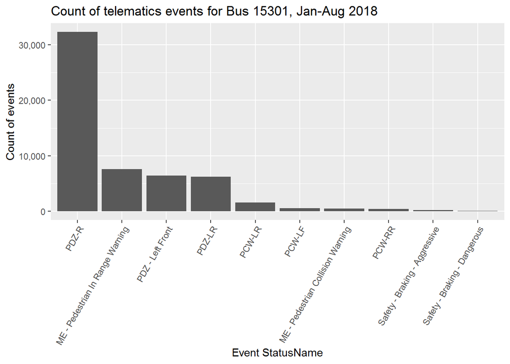

### Routes

Route shapefiles were accessed from the LA City GeoHub website. There are three three systems of bus routes:

- [Community DASH](http://geohub.lacity.org/datasets/community-dash-routes)
- [Downtown DASH](http://geohub.lacity.org/datasets/downtown-dash-routes)
- [Metro Bus lines](http://geohub.lacity.org/datasets/metro-bus-lines)

## Visual association

As a first pass, we present a visual demonstration that braking events do align with routes:

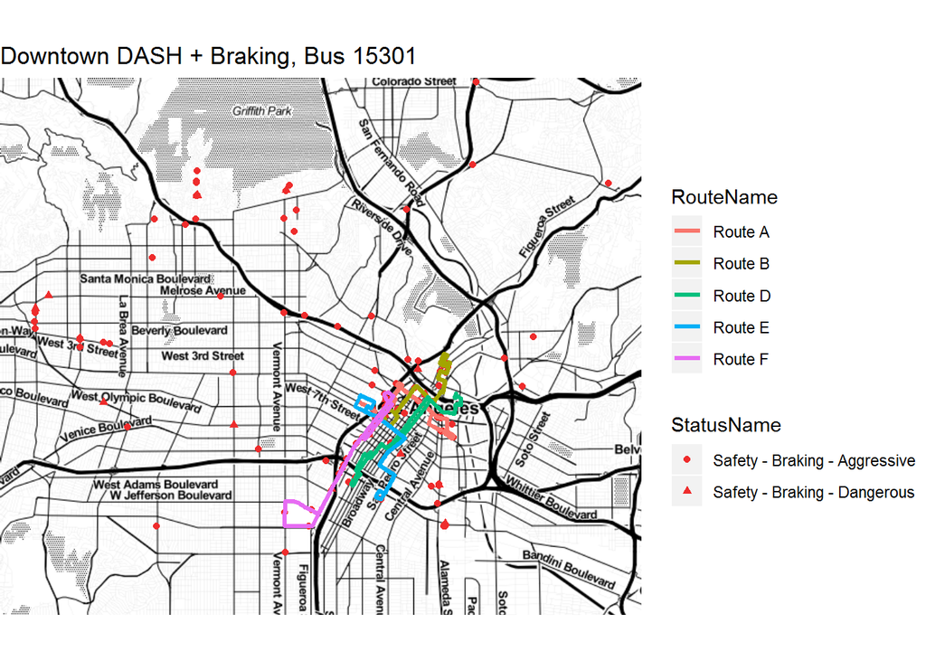

# Matching points to line

To associate events with routes, a standard geoprocessing method can be used. In the proprietary ESRI ArcMap software, the process is as follows:

- Add route and event data as layers, and with same projected coordinate system
- Use the “Near” tool, in ArcToolbox > Proximity > Near
- Events as inputs features, and Downtown DASH routes as near features The output of this process is two columns added to the Events file, one indicating which route is closest, other the distance to the nearest route in units of the projected data.

This same process can be carried out and automated using open source tools in the R statistical programming environment. In brief, the steps are as follows:

- Load route and event data as spatial points data frames, using the same projected coordinate system, which relies on the open source GDAL tools.
- Use the `gDistance` function to calculate distance between points to line segments, between the points (all warning and brakings) and each set of routes, which relies on the open source GEOS tools. The output of this process if three route x warning matrices, with distances for each event to each route. The three bus route systems (Downtown DASH, Community DASH, Metro Bus lines) are all considered possible associations for each event. The closest route is selected across the three systems (five events selected at random):

```
## 500  . 1000  . 1500  .
```

```
## 3.69 secs elapsed
```

```
## 500  .
```

```
## 1.73 secs elapsed
```

Distance (in miles) between five selected events and Downtown DASH routes

|  | ll.lat | ll.lon | dt_dash_route | dt_dash_dist | co_dash_route | co_dash_dist | metro_route | metro_dist | nearest.route | bus.system | maj.nearest.route | maj.bus.system | confidence |
| --- | --- | --- | --- | --- | --- | --- | --- | --- | --- | --- | --- | --- | --- |
| 34261 | 34.05640 | -118.2443 | B | 0.0019615 | LHCC | 0.2558250 | 4 | 0.0013711 | 4 | Metro Bus Line | B | Downtown DASH | 0.5000000 |
| 49275 | 34.05383 | -118.2559 | F | 0.0119387 | Pico Union | 0.4128597 | 55 | 0.0103550 | 55 | Metro Bus Line | F | Metro Bus Line | 0.4444444 |
| 37002 | 34.05512 | -118.2429 | B | 0.0017277 | LHCC | 0.2853420 | 92 | 0.0011985 | 92 | Metro Bus Line | B | Downtown DASH | 0.4189189 |
| 21196 | 34.05944 | -118.2368 | B | 0.0027464 | LHC | 0.0022421 | 76 | 0.0022407 | 76 | Metro Bus Line | B | Downtown DASH | 0.4893617 |
| 50411 | 34.05144 | -118.2560 | B | 0.0062615 | Pico Union | 0.4852515 | 442 | 0.0055543 | 442 | Metro Bus Line | B | Downtown DASH | 0.4594595 |

Checking output for a given day, looking at the individual event, hour, and hour-block route assignment results. Can filter by day and hour, and look to see how consistency of route assignment rises from ‘nearest.route’ to ‘maj.nearest.route’ (majority rule, by hour) to ‘maj.nearest.route.block’ (majority rule, by hour block).

|  | day | hour | nearest.route | bus.system | maj.nearest.route | maj.bus.system | confidence | maj.nearest.route.block | maj.bus.system.block | confidence.block |
| --- | --- | --- | --- | --- | --- | --- | --- | --- | --- | --- |
| 1 | 51 | 9 |  |  | 35 | Metro Bus Line | 0.666666666666667 | 35 | Metro Bus Line | 0.666666666666667 |
| 2 | 51 | 9 |  |  | 35 | Metro Bus Line | 0.666666666666667 | 35 | Metro Bus Line | 0.666666666666667 |
| 3 | 51 | 9 | Pico Union | Community DASH | 35 | Metro Bus Line | 0.666666666666667 | 35 | Metro Bus Line | 0.666666666666667 |
| 4 | 51 | 9 | 35 | Metro Bus Line | 35 | Metro Bus Line | 0.666666666666667 | 35 | Metro Bus Line | 0.666666666666667 |
| 5 | 51 | 9 | 35 | Metro Bus Line | 35 | Metro Bus Line | 0.666666666666667 | 35 | Metro Bus Line | 0.666666666666667 |
| 6 | 51 | 10 | FF | Community DASH | FF | Community DASH | 0.864864864864865 | FF | Community DASH | 0.907894736842105 |
| 7 | 51 | 10 | FF | Community DASH | FF | Community DASH | 0.864864864864865 | FF | Community DASH | 0.907894736842105 |
| 8 | 51 | 10 | FF | Community DASH | FF | Community DASH | 0.864864864864865 | FF | Community DASH | 0.907894736842105 |
| 9 | 51 | 10 | FF | Community DASH | FF | Community DASH | 0.864864864864865 | FF | Community DASH | 0.907894736842105 |
| 10 | 51 | 10 | FF | Community DASH | FF | Community DASH | 0.864864864864865 | FF | Community DASH | 0.907894736842105 |

[output cut: 5779 more lines]

Histograms of confidence by hour and hour block. When using three-hour time blocks, some of the low-confidence route assignments disappear, but average confidence is similar between the two methods.

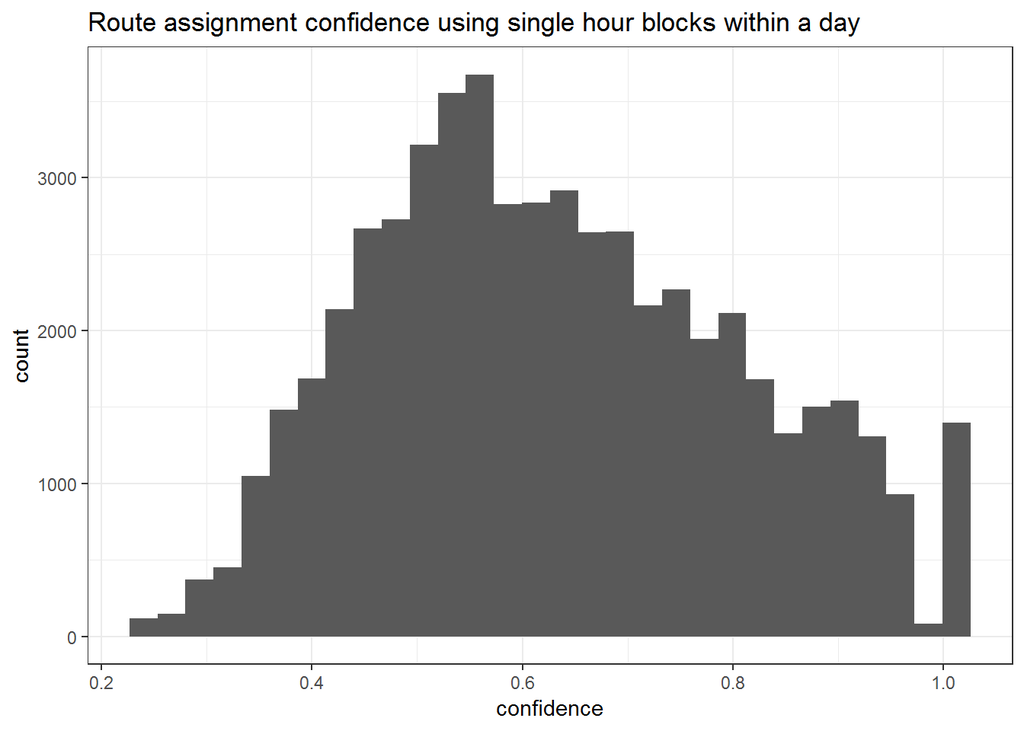

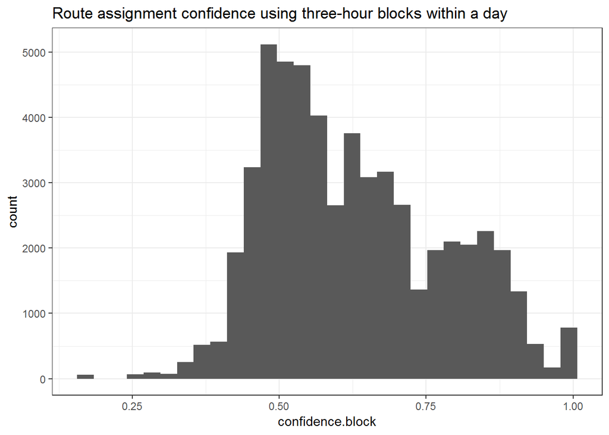

How consistently does this single bus drive the same routes? Is it safe to assume that a bus drives the same mix of routes in each week?

Count of events assigned to routes for Bus 15301

| route | route.count | Pct |
| --- | --- | --- |
| B Downtown DASH | 19575 | 35 |
| FF Community DASH | 10415 | 19 |
| F Downtown DASH | 5617 | 10 |
| A Downtown DASH | 4272 | 8 |
| BC Community DASH | 3684 | 7 |
| Obs Community DASH | 2095 | 4 |
| D Downtown DASH | 1543 | 3 |
| B Metro Bus Line | 1282 | 2 |
| HCC Community DASH | 1048 | 2 |
| HC Community DASH | 1006 | 2 |

Example week 15:

Count of events assigned to routes for Bus 15301, for week 15

| route | route.count | Pct |
| --- | --- | --- |
| B Downtown DASH | 1322 | 51 |
| BC Community DASH | 684 | 26 |
| A Downtown DASH | 554 | 21 |
| B Metro Bus Line | 24 | 1 |
| 210 Community DASH | 16 | 1 |
| NA NA | 2 | 0 |
| 14 Metro Bus Line | 1 | 0 |
| 2 Metro Bus Line | 1 | 0 |
| 10 Community DASH | 0 | 0 |
| 10 Metro Bus Line | 0 | 0 |

Example week 20:

Count of events assigned to routes for Bus 15301, for week 20

| route | route.count | Pct |
| --- | --- | --- |
| B Downtown DASH | 1467 | 46 |
| F Downtown DASH | 862 | 27 |
| A Downtown DASH | 544 | 17 |
| BC Community DASH | 265 | 8 |
| B Metro Bus Line | 45 | 1 |
| 66 Metro Bus Line | 9 | 0 |
| NA NA | 7 | 0 |
| 10 Community DASH | 0 | 0 |
| 10 Metro Bus Line | 0 | 0 |
| 105 Community DASH | 0 | 0 |

Example week 33:

Count of events assigned to routes for Bus 15301, for week 33

| route | route.count | Pct |
| --- | --- | --- |
| B Downtown DASH | 1072 | 35 |
| F Downtown DASH | 696 | 23 |
| A Downtown DASH | 494 | 16 |
| BC Community DASH | 337 | 11 |
| B Metro Bus Line | 190 | 6 |
| F Metro Bus Line | 155 | 5 |
| 442 Metro Bus Line | 74 | 2 |
| NA NA | 26 | 1 |
| B Community DASH | 22 | 1 |
| 18 Metro Bus Line | 8 | 0 |